# PA1_template.Rmd

Mohau Mateyisi

23 January 2019

## Loading and preprocessing the data

```r
library(data.table);
library(lubridate);
library(plyr)
Adata <- read.csv('file:///D:/Cousera/reproducible-research/activity.csv')
Adata$date<- dmy(Adata$date)
```

## What is mean total number of steps taken per day?

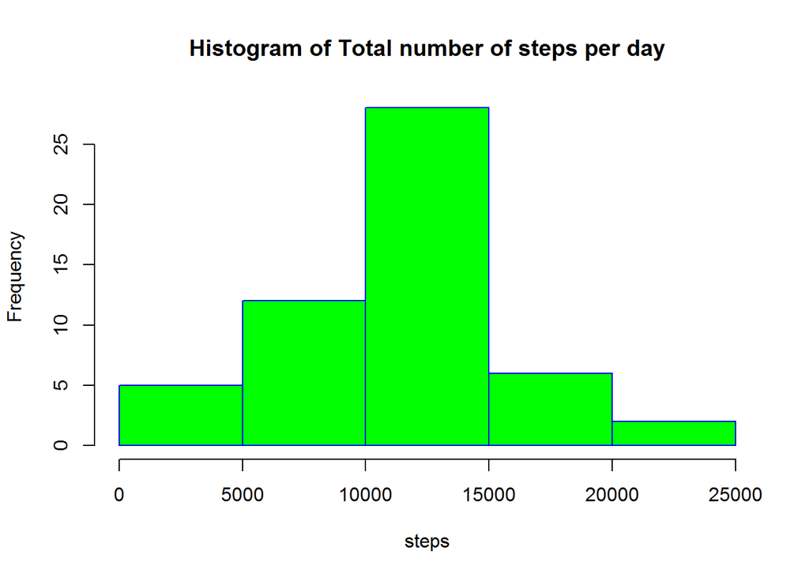

```r
dt2<-aggregate(steps ~ date , data = na.exclude(Adata), sum)

hist(dt2$steps,
     main="Histogram of Total number of steps per day",
     xlab="steps",
     border="blue",
     col="green")
```

```r
names(dt2)<-c("date","TtStepsPerDay")
ss<-summary(dt2)

minim  <-unlist(strsplit(ss[,"TtStepsPerDay"][1],":"))[2]
mediann <-unlist(strsplit(ss[,"TtStepsPerDay"][3],":"))[2]
meanv <-unlist(strsplit(ss[,"TtStepsPerDay"][4],":"))[2]
```

The mean and median number of steps are 10766 and 10765 respectively.

## What is the average daily activity pattern?

Below we plot the average daily activity pattern.

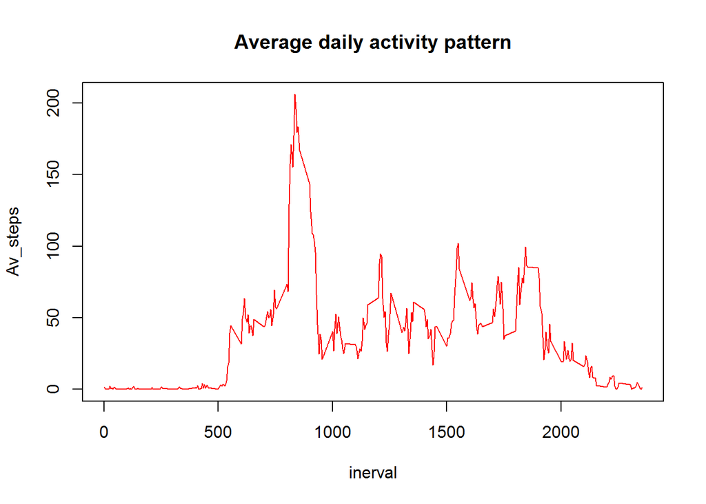

```r
library(ggplot2)
dtt2<-aggregate(steps ~ interval , data = na.exclude(Adata), mean)

with(dtt2, {
  plot(interval, steps, type="l", xlab="inerval", ylab="Av_steps", main="Average daily activity pattern", col="red")
})
```

```r
maximStepsInterval <-max(dtt2$interval)

# mean and median of the total number of steps per day.

meann1<-mean(dtt2$steps)
median1<- median(dtt2$steps)
```

## Imputing missing values

```r
library("imputeMissings")
```

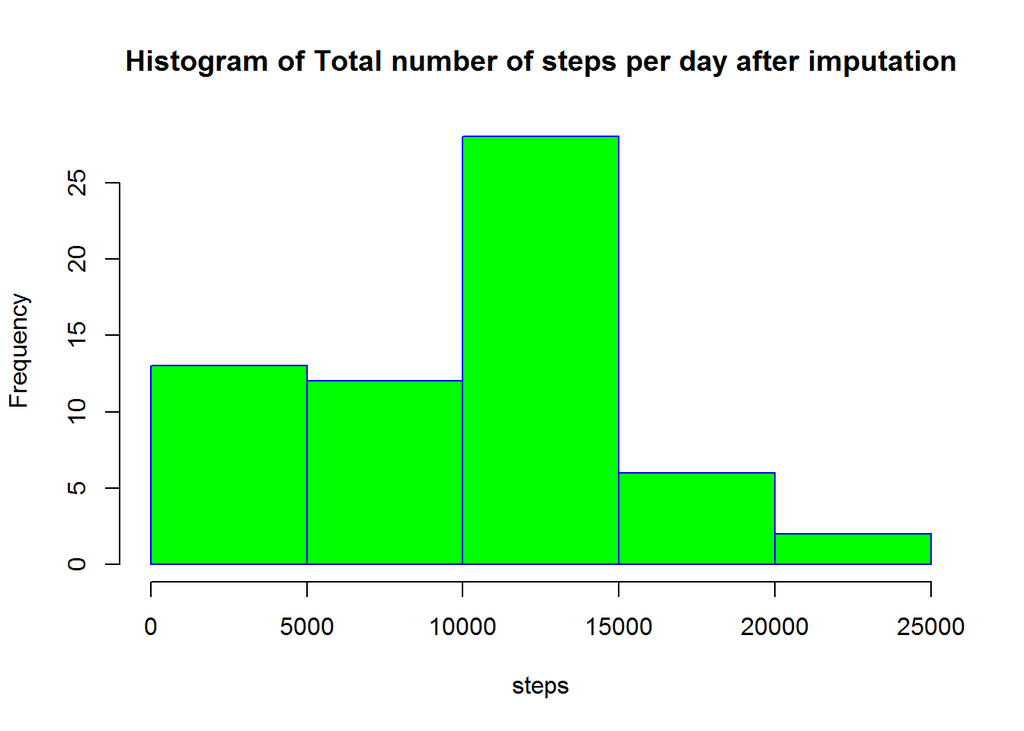

```r
Adata1<-Adata[,c("date","steps","interval")]

#impute with the median
r<-impute(Adata1, object = NULL, method = "median/mode", flag = FALSE)
zz<-summary(Adata)


dtt22<-aggregate(steps ~ date , data = na.exclude(r), sum)

hist(dtt22$steps,
     main="Histogram of Total number of steps per day after imputation",
     xlab="steps",
     border="blue",
     col="green")
```

```r
ismissing <-unlist(strsplit(zz[[7]],":"))[2]


dt22<-aggregate(steps ~ date , data = r, sum)

zz2 <- summary(dt22)

mmean<- unlist(strsplit(zz2[4,][2],":"))[2]
mmedian <-unlist(strsplit(zz2[3,][2],":"))[2]
```

There are about 2304 missing values.

The mean and median after data amputation are 9354 and 10395 .

The imputation process leads to a lower mean and median compared that obtained before replacing NA’s.

## Are there differences in activity patterns between weekdays and weekends?

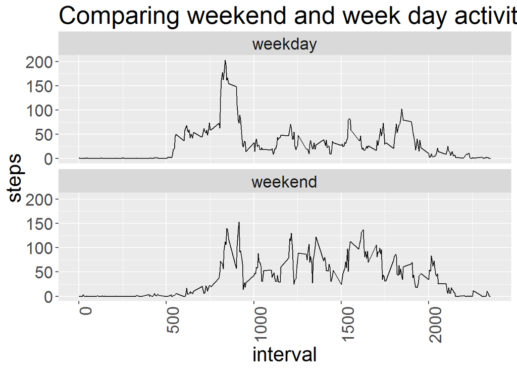

```r
library("ggplot2")
library("prettyR")
dt3<-r
dt3$weekday<-weekdays(r$date)

df1 = subset(dt3,dt3$weekday == "Saturday" | dt3$weekday == "Sunday")
df1<-aggregate(steps ~ interval , data = na.exclude(df1), mean)
df1$day<- "weekend"


df2 = subset(dt3,dt3$weekday != "Saturday" & dt3$weekday != "Sunday")
df2<-aggregate(steps ~ interval , data = na.exclude(df2), mean)
df2$day<-"weekday"


df3<-rbind(df1,df2)




p1 <-ggplot(df3, aes(interval,steps ))
p1 + geom_line(stat = "identity")+
   facet_wrap( ~ day, nrow = 2) + theme(legend.position = "none") +
   labs(title = "Comparing weekend and week day activities")+
   theme(text = element_text(size=20),
        axis.text.x = element_text(angle=90, hjust=1))
```

Between the 500 and 1000 time interval week day steps are much higher then the weekend steps. However, after the 1000 interval 5 min the average steps during the week are relatively lower than the average steps during the weekend.